# COMPSCIX 415.2 Homework 5/Midterm

## EDA

*Take a look at the txhousing data set that is included with the ggplot2 package and answer these questions:*

```r
data("txhousing")

#Question 1
txhousing %>%
 count(year)
```

```
## # A tibble: 16 x 2
##     year     n
##    <int> <int>
##  1  2000   552
##  2  2001   552
##  3  2002   552
##  4  2003   552
##  5  2004   552
##  6  2005   552
##  7  2006   552
##  8  2007   552
##  9  2008   552
## 10  2009   552
## 11  2010   552
## 12  2011   552
## 13  2012   552
## 14  2013   552
## 15  2014   552
## 16  2015   322
```

```r
#Question 2

 txhousing %>%
  summarise(num_cities = n_distinct(city))
```

```
## # A tibble: 1 x 1
##   num_cities
##        <int>
## 1         46
```

```r
#Question 3
txhousing %>%
select(city,year,month,sales) %>%
 arrange(-sales)
```

```
## # A tibble: 8,602 x 4
##    city     year month sales
##    <chr>   <int> <int> <dbl>
##  1 Houston  2015     7  8945
##  2 Houston  2006     6  8628
##  3 Houston  2013     7  8468
##  4 Houston  2015     6  8449
##  5 Houston  2013     5  8439
##  6 Houston  2014     6  8391
##  7 Houston  2014     7  8391
##  8 Houston  2014     8  8167
##  9 Houston  2013     8  8155
## 10 Houston  2006     5  8040
## # ... with 8,592 more rows
```

```r
#Question 4
txhousing %>%
summarize(listing_sales_corr = cor(listings, sales, use = "complete.obs"))
```

```
## # A tibble: 1 x 1
##   listing_sales_corr
##                <dbl>
## 1              0.921
```

```r
#Question 5
missing_city <- txhousing %>%
mutate(missing= (is.na(sales)))%>%
select(city, missing)

missing_city %>%
group_by(city) %>%
summarize(missing_sum = mean(missing))%>%
arrange(-missing_sum)
```

```
## # A tibble: 46 x 2
##    city               missing_sum
##    <chr>                    <dbl>
##  1 South Padre Island      0.620
##  2 Kerrville               0.556
##  3 Midland                 0.401
##  4 Odessa                  0.385
##  5 San Marcos              0.246
##  6 Laredo                  0.193
##  7 Harlingen               0.134
##  8 Waco                    0.102
##  9 Texarkana               0.0909
## 10 Brazoria County         0.0749
## # ... with 36 more rows
```

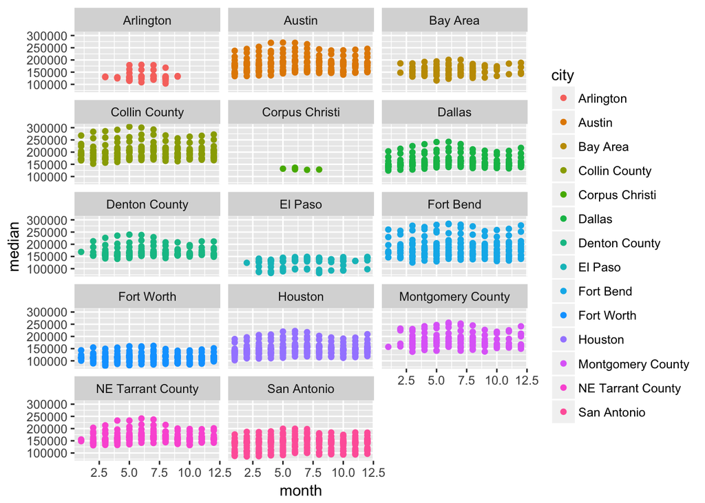

```r
#Question 6

filtered_housing <-txhousing %>%
group_by(city,year, month)%>%
filter(sales>500)

ggplot(data = filtered_housing) +
  geom_point(mapping = aes(x = month, y = median, color=city))+
  facet_wrap(~ city, nrow = 5)
```

*1. During what time period is this data from?*

This data is from 2000 - 2015.

*2. How many cities are represented?*

46 cities are represented.

*3. Which city, month and year had the highest number of sales?*

Houston in July 2015 has the highest number of sales.

*4. What kind of relationship do you think exists between the number of listings and the number of sales? Check your assumption and show your work.*

My hypothesis is that there is a positive relationship between the number of listings and the number of sales. I checked my assumption by computing the correlation between these two variables and was correct. The correlation is very high at 0.92.

*5. What proportion of sales is missing for each city?*

See above R output. South Padre Island is missing the most sales data.

*6. Looking at only the cities and months with greater than 500 sales: (a) Are the distributions of the median sales price (column name median), when grouped by city,different? The same? Show your work. (b)Any cities that stand out that you’d want to investigate further? (c) Why might we want to filter out all cities and months with sales less than 500?*